# Expresión Diferencial

Rodolfo Chávez

2022-05-07

# I. Objetivos

- Conocer el flujo de trabajo empleado en el análisis bioinformático de datos obtenidos por *RNA-seq*
- Explicar el análisis de expresión diferencial empleando DESeq2
- Analizar un conjunto de datos de expresión empleando un script de DESEq2

# II. Requisitos

Esta práctica está basada en el flujo de trabajo o *pipeline* de [Michael Love](https://bioconductor.org/packages/release/workflows/vignettes/rnaseqGene/inst/doc/rnaseqGene.html) por lo que requerirémos de:

## Datos

Los datos fueron descargados de un proyecto público titulado **NRF2 signalling associated with radioresistance in colorectal cancer models** de la base de datos [GEO](https://www.ncbi.nlm.nih.gov/geo/query/acc.cgi?acc=GSE136011). El número de acceso del trabajo es **GSE136011**. Los datos que requeriremos para la práctico serán:

- En formato **FastQ** para iniciar la prácitca desde el inicio
- Las cuentas crudas generadas por *Salmon* ubicadas en este vínculo
- Los objetos de R para iniciar el análisis de expresión diferencial. Se ubican en el siguiente vínculo

## Programas

### Shell

Descarga e instala los programas empleando el gestor de paquetes de python **[Conda](https://conda.io/projects/conda/en/latest/user-guide/install/index.html)**. Sigue las instrucciones específicas para tu sistema operativo desde la opción *Regular installation*. Una vez que hayas descargado e instalado correctamente conda, prueba el siguiente comando:

```bash
conda list
```

Instala los siguientes programas:

- FastQC
- MultiQC
- Cutadapt
- Salmon

Corriendo el comando:

```bash
conda install -c  bioconda <paquete>
```

### R

Los paquetes de R que vas a emplear en la práctica se descargarán desde los repositiorios de **Bioconductor** y **CRAN**. Para ello asegurate que tienes instalada la **última versión** de **[R](https://cran.itam.mx/)** y la IDE de **[RStudio](https://www.rstudio.com/products/rstudio/download/)**. Una vez configurado correctamente R, procede a instalar la **última versión** de Bioconductor corriendo el siguiente comando:

```r
install.packages("BiocManager")
BiocManager::install(version = 3.13)
```

Instalado Bioconductor, descarga e instala los siguientes paquetes:

- tximeta
- DESeq2
- PCAtools
- apeglm
- Glimma
- clusterProfiler
- enrichplot
- biomaRt
- fgsea

Corriendo el siguiente comando:

```r
BiocManager::install("paquete")
```

Los paquetes que descargaremos desde CRAN son:

- tidyverse
- RColorBrewer
- pheatmap
- here

Corriendo el comando:

```r
install.packages("paquete")
```

# III. Análisis bioinformático de los datos de secuenciación

Si decides realizar el ejercicio desde el inicio, empieza desde este punto. De lo contrario salta a la sección 4.2

## 1. Control de calidad de las secuencias crudas

- Primer paso a realizar en los flujos de trabajo para el análisis de expresión diferencial. A este proceso también se le conoce como *Quality Control* o *QC analysis*
- Permite verificar la calidad de las lecturas a distintos niveles:
  - Asignación de bases
  - Secuencias duplicadas
  - Presencia de contaminación específica o inespecífica

Pasos para correr **FastQC**

1. Abre una ventana de la terminal y ubicate en el directorio `bin/` del presente repositorio
2. Activa tu ambiente de conda corriendo:

```bash
conda activate <ruta al directorio miniconda2 o minicoda3>
```

3. Comprueba que el programa FastQC se encuentra correctamente instalado:

```bash
fastqc -h
```

4. Analiza la calidad de las secuencias crudas:

```bash
fastqc ../data/*.fastq.gz -o ../Output/FastQC/
```

Para concatenar o juntar los resultados de todas las muestras analizadas por FastQC, usemos **MultiQC**

1. Corrobora que MultiQC se encuentra correctamente instalado:

```bash
multiqc -h
```

2. Ejecuta el programa para analizar los archivos con terminación `.zip` generados por FastQC

```bash
multiqc ../Output/FastQC/*.zip -o ../Output/MultiQC/
```

Explora y revisa los archivos generados por FastQC y MultiQC

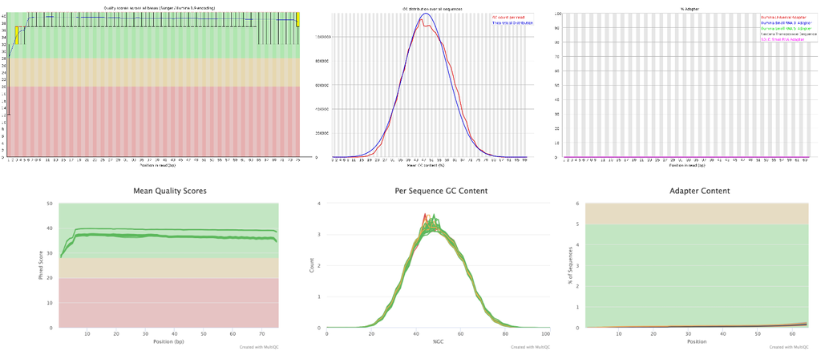

Importante revisar si los problemas detectados por FastQC en la calidad de las secuencias se presentan en una, varias o todas las muestras porque de esto dependerán las correcciones a las lecturas crudas para mejorar su calidad.

## 2. Limpieza y corrección de la calidad de las lecturas

- Proceso que depende de los resultados del QC
- Permite:
  - Filtrar las lecturas para seleccionar aquellas que tengan mayor calidad
  - Recortar lecturas para preservar los fragmentos de mayor calidad
  - Recortar lecturas para eliminar secuencias contaminantes (adaptadores)

Pasos para correr **Cutadapt**:

1. De manera similar al análisis anterior, asegura que te encuentras en el directorio `bin/`, tienes activo el ambiente de conda y `cutadapt` se encuentra correctamente instalado:

```bash
cutadapt -h
```

2. Ejecuta `cutadapt` para una sola muestra:

```bash
cutadapt -a AATGATACGGCGACCACCGAGATCTACACTCTTTCCCTACACGACGCTCTTCCGATCT ##Para el read forward
-A AATGATACGGCGACCACCGAGATCTACACTCTTTCCCTACACGACGCTCTTCCGATCT ##Para el read reverse
-o ../Output/Cutadapt/samp1_clean_R1.fastq.gz ##Archivo de salida para las lecturas forward
-p ../Output/Cutadapt/samp1_clean_R2.fastq.gz ##Archivo de salida para las lecturas reverse
../data/samp1_R1.fastq.gz ##Ruta hacia las lecturas crudas forward
../data/samp1_R2.fastq.gz ##Ruta hacia las lecturas crudas reverse
```

Para ejecutar `cutadapt` en todas las muestras abre el archivo titulado `2.Read_cleaning` en el directorio `bin/` y encotrarás el código anidado en un bucle o *for loop*. Desde la terminal corre:

```bash
bash 2.Read_cleaning
```

Al finalizar el filtrado y recorte o *triming* de la secuencias crudas, vuelve a analizar la calidad con `fastQC` y `MultiQC` de las lecturas limpias.

## 3. Alineamiento, mapeo y estimación de la abundancia de las lecturas

- Proceso necesario para conocer la región del genoma o transcriptoma a partir de la cual se generaron las lecturas
- Permita anotar las lecturas y categorizarlas como: mRNA, lncRNA, ncRNA, miRNA, …
- Estimación del número de lecturas a nivel de gen, isoforma, exón, …

Aunque `Salmon` es un pseudoalineador y no requiere de mayor uso de recursos computacionales comparado con `STAR`, `HISAT2` o `Tophat2`, es recomendable que el proceso lo realices en un *cluster* para que lo paralelices.

2. Correr el siguiente código para generar el índice:

```bash
salmon index -t ../reference/Homo_sapiens.GRCh38.cdna.all.fa ##Ruta hacia el archivo fasta del transcriptoma de referencia
-i ../reference/hsa_v38_gencode ##Ruta para almacenar los archivos generados del índice
```

3. Una vez generado el índice, realizar el pseudoalineamiento para una muestra:

```bash
salmon quant -i ../reference/hsa_v38_gencode ##Ruta hacia el índice
-l A ##Opción para permitir a salmon deducir de forma automática las características de la libreria
-1 ../Output/Cutadapt/samp1_clean_R1.fastq.gz ##Ruta a las lecturas forward
-2 ../Output/Cutadapt/samp1_clean_R2.fastq.gz ##Ruta a las lecturas reverse
-p 8 ##Número de cores para paralelizar el proceso
--validateMappings -o ##Opción  para permitir a salmon validar los archivos bam generados de forma temporal
../Output/salmon_quants/samp1_quant ##Ruta para guardar las cuentas crudas generadas por salmon
```

Si deseas realizar este proceso para todas las muestras, corre el siguiente código:

```bash
bash 3.Pseudoalignment
```

## 4. Análisis de expresión diferencial

### 4.1 Importe de archivos a R

Al finalizar el proceso de estimación de la abundancia, Salmon nos devuelve los siguientes archivos por muestra:

```bash
ls ../results/salmon_quants/
```

```
## metadata.txt
## samp10_quant
## samp11_quant
## samp12_quant
## samp1_quant
## samp2_quant
## samp3_quant
## samp4_quant
## samp5_quant
## samp6_quant
## samp7_quant
## samp8_quant
## samp9_quant
```

- Generadas por `salmon`
- Preserva metadatos asociados al proceso de pseudoalineamiento (versión del transcriptoma de referencia, código empleado, versión del pseudoalineador, …)

Para importar los datos a R vamos a requerir de una tabla de metadatos en formato de texto plano

```r
list.files(here("results/salmon_quants/"))
```

```
##  [1] "metadata.txt" "samp1_quant"  "samp10_quant" "samp11_quant" "samp12_quant"
##  [6] "samp2_quant"  "samp3_quant"  "samp4_quant"  "samp5_quant"  "samp6_quant"
## [11] "samp7_quant"  "samp8_quant"  "samp9_quant"
```

1. Cargar a R la tabla de metadatos:

```r
coldata <- read.table(here("results/salmon_quants/metadata.txt"), he = T, stringsAsFactors = T, sep = "\t")

rownames(coldata) <- coldata$unique_id

head(coldata)
```

```
##                                                                                   file_name
## siRNA_NRF2_1        SRR10004274_GSM4039376_NRF2_siRNA_rep_1_Homo_sapiens_RNA-Seq_1.fastq.gz
## siRNA_control_1 SRR10004275_GSM4039377_NRF2_siRNA_cont_rep1_Homo_sapiens_RNA-Seq_1.fastq.gz
## siRNA_NRF2_2        SRR10004276_GSM4039378_NRF2_siRNA_rep_2_Homo_sapiens_RNA-Seq_1.fastq.gz
## siRNA_control_2 SRR10004277_GSM4039379_NRF2_siRNA_cont_rep2_Homo_sapiens_RNA-Seq_1.fastq.gz
## siRNA_NRF2_3        SRR10004278_GSM4039380_NRF2_siRNA_rep_3_Homo_sapiens_RNA-Seq_1.fastq.gz
## siRNA_control_3 SRR10004279_GSM4039381_NRF2_siRNA_cont_rep3_Homo_sapiens_RNA-Seq_1.fastq.gz
##                     Treatment Replicate       unique_id   key Geno
## siRNA_NRF2_1       siRNA_NRF2         1    siRNA_NRF2_1 samp1   WT
## siRNA_control_1 siRNA_control         1 siRNA_control_1 samp2   WT
## siRNA_NRF2_2       siRNA_NRF2         2    siRNA_NRF2_2 samp3   WT
## siRNA_control_2 siRNA_control         2 siRNA_control_2 samp4   WT
## siRNA_NRF2_3       siRNA_NRF2         3    siRNA_NRF2_3 samp5   WT
## siRNA_control_3 siRNA_control         3 siRNA_control_3 samp6   WT
```

2. Crear una nueva columna a la tabla que incluya la ruta hacia los archivos de las cuentas crudas generados por `salmon`:

```r
coldata <- dplyr::mutate(coldata, files = file.path(here("results/salmon_quants"), paste0(coldata$key, "_quant"), "quant.sf"))
```

3. Verificar que las rutas hacia los archivos de las cuentas fue correctamente creada:

```r
coldata <- mutate(coldata, file_exist = file.exists(coldata$files))

coldata[, 2:8]
```

```
##                     Treatment Replicate       unique_id    key Geno
## siRNA_NRF2_1       siRNA_NRF2         1    siRNA_NRF2_1  samp1   WT
## siRNA_control_1 siRNA_control         1 siRNA_control_1  samp2   WT
## siRNA_NRF2_2       siRNA_NRF2         2    siRNA_NRF2_2  samp3   WT
## siRNA_control_2 siRNA_control         2 siRNA_control_2  samp4   WT
## siRNA_NRF2_3       siRNA_NRF2         3    siRNA_NRF2_3  samp5   WT
## siRNA_control_3 siRNA_control         3 siRNA_control_3  samp6   WT
## CT_1                       CT         1            CT_1  samp7   WT
## mut_NRF2_1           mut_NRF2         1      mut_NRF2_1  samp8  Mut
## CT_2                       CT         2            CT_2  samp9   WT
## mut_NRF2_2           mut_NRF2         2      mut_NRF2_2 samp10  Mut
## CT_3                       CT         3            CT_3 samp11   WT
## mut_NRF2_3           mut_NRF2         3      mut_NRF2_3 samp12  Mut
##                                                                                                       files
## siRNA_NRF2_1     /Users/rodolfochavez/RNAseq/Tutorial_of_RNA_seq/results/salmon_quants/samp1_quant/quant.sf
## siRNA_control_1  /Users/rodolfochavez/RNAseq/Tutorial_of_RNA_seq/results/salmon_quants/samp2_quant/quant.sf
## siRNA_NRF2_2     /Users/rodolfochavez/RNAseq/Tutorial_of_RNA_seq/results/salmon_quants/samp3_quant/quant.sf
## siRNA_control_2  /Users/rodolfochavez/RNAseq/Tutorial_of_RNA_seq/results/salmon_quants/samp4_quant/quant.sf
## siRNA_NRF2_3     /Users/rodolfochavez/RNAseq/Tutorial_of_RNA_seq/results/salmon_quants/samp5_quant/quant.sf
## siRNA_control_3  /Users/rodolfochavez/RNAseq/Tutorial_of_RNA_seq/results/salmon_quants/samp6_quant/quant.sf
## CT_1             /Users/rodolfochavez/RNAseq/Tutorial_of_RNA_seq/results/salmon_quants/samp7_quant/quant.sf
## mut_NRF2_1       /Users/rodolfochavez/RNAseq/Tutorial_of_RNA_seq/results/salmon_quants/samp8_quant/quant.sf
## CT_2             /Users/rodolfochavez/RNAseq/Tutorial_of_RNA_seq/results/salmon_quants/samp9_quant/quant.sf
## mut_NRF2_2      /Users/rodolfochavez/RNAseq/Tutorial_of_RNA_seq/results/salmon_quants/samp10_quant/quant.sf
## CT_3            /Users/rodolfochavez/RNAseq/Tutorial_of_RNA_seq/results/salmon_quants/samp11_quant/quant.sf
## mut_NRF2_3      /Users/rodolfochavez/RNAseq/Tutorial_of_RNA_seq/results/salmon_quants/samp12_quant/quant.sf
##                 file_exist
## siRNA_NRF2_1          TRUE
## siRNA_control_1       TRUE
## siRNA_NRF2_2          TRUE
## siRNA_control_2       TRUE
## siRNA_NRF2_3          TRUE
## siRNA_control_3       TRUE
## CT_1                  TRUE
## mut_NRF2_1            TRUE
## CT_2                  TRUE
## mut_NRF2_2            TRUE
## CT_3                  TRUE
## mut_NRF2_3            TRUE
```

4. `tximeta` requiere que exista una columna en la tabla de metadatos llamada **names** y que incluya el nombre de los directorios en donde se encuentra almacenadas las cuentas por cada muestra (samp1_quant)

```r
coldata <- mutate(coldata, names = paste0(coldata$key, "_quant"))
```

5. Si todas las rutas fueron creadas correctamente, importa los datos usando `tximeta`

```r
se <- tximeta(coldata)
```

```
## importing quantifications
```

```
## reading in files with read_tsv
```

```
## 1 2 3 4 5 6 7 8 9 10 11 12
```

```
## found matching transcriptome:
## [ Ensembl - Homo sapiens - release 103 ]
```

```
## loading existing EnsDb created: 2021-03-09 20:52:43
```

```
## loading existing transcript ranges created: 2021-03-09 20:52:48
```

Ya que `tximeta` descarga información relacionada con el transcriptoma de referencia, este último paso requiere de una conexión estable a internet de alta velocidad por lo que puede llegar a tardar el proceso.

6. El objeto `se` tiene clase de *SummarizedExperiment* y las cuentas están reportadas a nivel de transcrito (isoforma). Para obtener las cuentas a nivel de gen:

```r
gse <- summarizeToGene(se)
```

```
## loading existing EnsDb created: 2021-03-09 20:52:43
```

```
## obtaining transcript-to-gene mapping from database
```

```
## loading existing gene ranges created: 2021-03-09 20:53:45
```

```
## summarizing abundance
```

```
## summarizing counts
```

```
## summarizing length
```

Explora el objeto gse (*SummarizedExperiment*)

```r
##Acceder a la  tabla de metadatos
colData(gse)

##Acceder al objeto GRanges con la información de los rangos y anotación de cada gen
head(rowRanges(gse))

##Acceder a la matriz de cuantas crudas
head(assay(gse))
```

### 4.2 Cargando los archivos desde el objeto .rdata

Si has decidido comenzar con el ejercicio desde este punto, solo necesitas cargar el objeto `SummarizedExperimentObj.rdata` ubicado en el folder llamado `data/`

```r
##Carga el archivo usando la función load
load("../data/SummarizedExperimentObj.rdata")
```

Verifica que en el ambiente de R se cargaron correctamente los siguientes objetos:

- dds
- gse
- se

### Exploración de los datos

Previamente al análisis de expresión diferencial, es necesario explorar los datos:

- Conocer la estructura del set de datos
- Detectar consistencia entre réplicas
- Visualizar comportamientos atípicos (*outliers*)
- Reportar las variables que separan o agrupan los datos

El **análisis de componentes principales** (PCA) nos permita reducir la dimensionalidad de nuestro set de datos y analizarlos de manera más intuitiva.

Los pasos para explorar el juego de datos son los siguientes:

1. Crear un objeto `DESeq` (*SummarizedExperiment*) a partir del objeto `gse`

```r
dds <- DESeqDataSet(se = gse, ##Objeto SummarizedExperiment que contiene la matriz de cuentas crudas
                    design = ~ Treatment) ##Variable con los grupos experimentales a contrastar. Forma parte de las columnas de coldata
```

```
## using counts and average transcript lengths from tximeta
```

2. Visualizar el grupo de referencia o **control** de la variable seleccionada

```r
##El primer nivel o elemento es el grupo control  ("CT")
levels(dds$Treatment)
```

```
## [1] "CT"            "mut_NRF2"      "siRNA_control" "siRNA_NRF2"
```

3. Dependiendo de la pregunta a responder, recodifica el grupo de referencia:

```r
dds$Treatment <- relevel(dds$Treatment, "siRNA_control")

levels(dds$Treatment)
```

```
## [1] "siRNA_control" "CT"            "mut_NRF2"      "siRNA_NRF2"
```

4. Ya que los genes que muestran bajo número de cuentas (abundancia) no nos interesan en el análisis, selecciona aquellos que muestran mayor abundancia usando un punto de corte:

```r
##Recupera los genes que muestran más de 1 cuenta en al menos 3 muestras
keep <- rowSums(counts(dds) >= 1) >=3

##Visualiza cuántos genes pasaron el filtro de abundancia
table(keep)
```

```
## keep
## FALSE  TRUE
## 16846 21299
```

```r
##Corta los genes que pasaron el filtro de abundancia del objeto dds
dds <- dds[keep, ]
```

5. Para explorar los datos por medio del PCA necesitamos normalizar las cuentas crudas para que los datos sean más comparables entre sí. Empleamos la transformación *regularized-logarithm transformation* recomendada para juegos de datos con una n < 30:

```r
rld <-  rlog(dds, blind = F)
```

```
## using 'avgTxLength' from assays(dds), correcting for library size
```

6. Realiza el PCA empleando el paquete `PCAtools`:

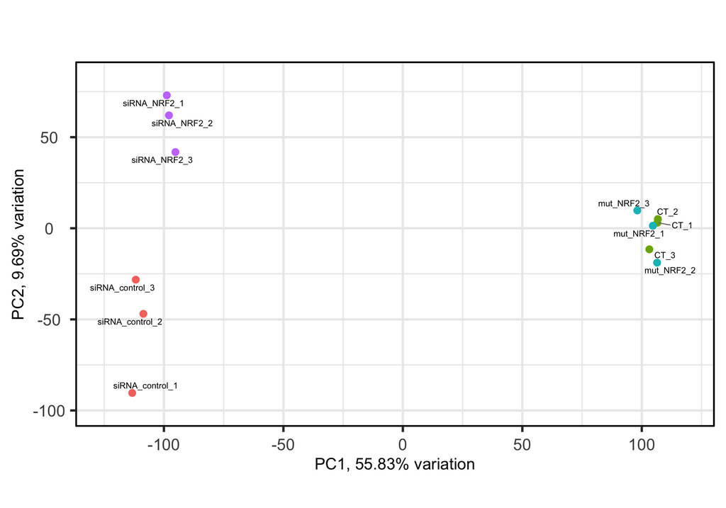

```r
##Indicarle a  la función pca que los datos deben de ser escalados para que sean más comparables entre sí
pca <- pca(assay(rld), metadata = colData(rld), scale = T)

##Graficar el resultado del PCA mostrando las etiquetas de acuerdo al nombr + tratamiento + réplica y coloreando los puntos de acuerdo al tipo de tratamiento
biplot(pca, lab = rownames(colData(rld)), colby = "Treatment")
```

- ¿Cuál es la estructura del juego de datos?
- ¿Cuál fue la variable que causó dicho separamiento?
- ¿Existen datos *outlier*?
- ¿La consistencia entre las réplicas es adecuada?

Si deseas generar una gráfica interactiva de un análisis de reducción de dimensiones, utiliza la funcion `glimmaMDS()` del paquete `Glimma` la cual realiza un escalamiento multidimensional del set de datos.

### Análisis de expresión diferencial

El análisis de expresión diferencial en `DESeq2` se encuentra completamente automatizado. Al correr la función `DESeq()`, el programa:

- Emplea el método de las medianas de los ratios para calcular los factores de escalación (size-factors) y normalizar las cuentas crudas.
- Estima la dispersión de cada gen (réplicas biológicas cobran importancia)
- Ajusta los datos a un modelo binomial negativo linearizado (GLM)
- Realiza la prueba de Wald para comparar los coeficientes asociados a cada gen (log2FC y padj)

El análisis de expresión diferencial en `DESeq2` se lleva a cabo de la siguiente forma:

1. Corre la función `DESeq()` para normalizar, estimar la dispersión y ajustar los datos al modelo binomial negativo.

```r
dds  <- DESeq(dds)
```

```
## using 'avgTxLength' from assays(dds), correcting for library size
```

2. Realiza la prueba estadística para obtener los genes diferencialmente expresados:

```r
##Usemos la función results con los parámetros por default
res <- results(dds)

##Visualiza el objeto que contiene los resultados
res
```

```
## log2 fold change (MLE): Treatment siRNA NRF2 vs siRNA control
## Wald test p-value: Treatment siRNA NRF2 vs siRNA control
## DataFrame with 21299 rows and 6 columns
##                    baseMean log2FoldChange     lfcSE       stat      pvalue
##                   <numeric>      <numeric> <numeric>  <numeric>   <numeric>
## ENSG00000000003 1497.757504      0.0982849 0.0902643   1.088857 2.76217e-01
## ENSG00000000419 1789.280526     -0.0107935 0.0702472  -0.153650 8.77885e-01
## ENSG00000000457  304.687311     -0.0243559 0.1151762  -0.211466 8.32523e-01
## ENSG00000000460  467.602306      0.5142010 0.1159843   4.433368 9.27721e-06
## ENSG00000000938    0.618937      1.3390032 2.8076874   0.476906 6.33429e-01
## ...                     ...            ...       ...        ...         ...
## ENSG00000288690    8.913454      0.0326943  0.663455  0.0492789    0.960697
## ENSG00000288694    0.258397      0.8179394  4.365460  0.1873661    0.851374
## ENSG00000288695   11.159112     -0.3769746  0.701013 -0.5377567    0.590745
## ENSG00000288698   23.403296      0.5109625  1.060520  0.4818036    0.629946
## ENSG00000288699    0.869679      1.5093784  3.007207  0.5019203    0.615724
##                        padj
##                   <numeric>
## ENSG00000000003 0.476825323
## ENSG00000000419 0.948127083
## ENSG00000000457 0.924197635
## ENSG00000000460 0.000121719
## ENSG00000000938          NA
## ...                     ...
## ENSG00000288690    0.980632
## ENSG00000288694          NA
## ENSG00000288695    0.768387
## ENSG00000288698    0.795601
## ENSG00000288699          NA
```

```r
##Obten el número de genes sobre- y sub-expresados de acuerdo a la prueba estadística
summary(res)
```

```
##
## out of 21299 with nonzero total read count
## adjusted p-value < 0.1
## LFC > 0 (up)       : 2271, 11%
## LFC < 0 (down)     : 2660, 12%
## outliers [1]       : 26, 0.12%
## low counts [2]     : 5778, 27%
## (mean count < 8)
## [1] see 'cooksCutoff' argument of ?results
## [2] see 'independentFiltering' argument of ?results
```

Aspectos importantes al correr la función `results()` con los parámetros por default:

- El contraste entre grupos experimentales de la variable tratamiento se realizó entre el factor re-codificado como control (siRNA_cotnrol) y el último factor de la variable (siRNA_NRF2), es decir, **siRNA_NRF2 vs siRNA_control**
- El punto de corte de expresión (log2FoldChange) fue de 0
- El punto de corte estadístico fue de padj < 0.1

…En otras palabras, estás recuperando genes que se expresan más de una o menos de una vez con respecto al control y aceptando 10 resultados falsos positivos por cada 100 pruebas…

¿Podemos modificar el contraste y los *threshold* de expresión y estadísticos?… **¡Sí!**

Para modificar las variables a contrastar:

```r
##Corre la función results names para conocer los contrastes disponibles
resultsNames(dds)
```

```
## [1] "Intercept"
## [2] "Treatment_CT_vs_siRNA_control"
## [3] "Treatment_mut_NRF2_vs_siRNA_control"
## [4] "Treatment_siRNA_NRF2_vs_siRNA_control"
```

```r
##Elige el contraste de tu preferencia y especificalo en el argumento contrast de la función  res
results(dds, contrast = c("Treatment", "mut_NRF2", "siRNA_control"))
```

```
## log2 fold change (MLE): Treatment mut_NRF2 vs siRNA_control
## Wald test p-value: Treatment mut NRF2 vs siRNA control
## DataFrame with 21299 rows and 6 columns
##                    baseMean log2FoldChange     lfcSE      stat      pvalue
##                   <numeric>      <numeric> <numeric> <numeric>   <numeric>
## ENSG00000000003 1497.757504      -0.904490 0.0925777  -9.77006 1.51357e-22
## ENSG00000000419 1789.280526      -0.463760 0.0712266  -6.51105 7.46273e-11
## ENSG00000000457  304.687311      -0.132462 0.1169467  -1.13267 2.57352e-01
## ENSG00000000460  467.602306       1.197748 0.1136246  10.54128 5.57374e-26
## ENSG00000000938    0.618937       0.569104 2.8961996   0.19650 8.44219e-01
## ...                     ...            ...       ...       ...         ...
## ENSG00000288690    8.913454      -3.275897  0.903258 -3.626757 0.000287003
## ENSG00000288694    0.258397      -1.020007  4.407356 -0.231433 0.816978494
## ENSG00000288695   11.159112      -0.264531  0.698382 -0.378777 0.704853537
## ENSG00000288698   23.403296       1.095652  1.055949  1.037600 0.299456461
## ENSG00000288699    0.869679       0.823637  3.075925  0.267769 0.788877177
##                        padj
##                   <numeric>
## ENSG00000000003 8.25857e-22
## ENSG00000000419 2.39298e-10
## ENSG00000000457 3.36544e-01
## ENSG00000000460 3.44774e-25
## ENSG00000000938          NA
## ...                     ...
## ENSG00000288690 0.000587388
## ENSG00000288694          NA
## ENSG00000288695 0.771544281
## ENSG00000288698 0.383276923
## ENSG00000288699 0.839628917
```

Para modificar los *threshold* de expresión y estadístico:

```r
##Emplea los argumentos lfcthreshold y alpha para especificar ambos puntos de corte de forma simultánea
res_LFC <- results(dds, lfcThreshold = 1, alpha = 0.05)

res_LFC
```

```
## log2 fold change (MLE): Treatment siRNA NRF2 vs siRNA control
## Wald test p-value: Treatment siRNA NRF2 vs siRNA control
## DataFrame with 21299 rows and 6 columns
##                    baseMean log2FoldChange     lfcSE      stat    pvalue
##                   <numeric>      <numeric> <numeric> <numeric> <numeric>
## ENSG00000000003 1497.757504      0.0982849 0.0902643  0.000000  1.000000
## ENSG00000000419 1789.280526     -0.0107935 0.0702472  0.000000  1.000000
## ENSG00000000457  304.687311     -0.0243559 0.1151762  0.000000  1.000000
## ENSG00000000460  467.602306      0.5142010 0.1159843  0.000000  1.000000
## ENSG00000000938    0.618937      1.3390032 2.8076874  0.120741  0.903896
## ...                     ...            ...       ...       ...       ...
## ENSG00000288690    8.913454      0.0326943  0.663455  0.000000  1.000000
## ENSG00000288694    0.258397      0.8179394  4.365460  0.000000  1.000000
## ENSG00000288695   11.159112     -0.3769746  0.701013  0.000000  1.000000
## ENSG00000288698   23.403296      0.5109625  1.060520  0.000000  1.000000
## ENSG00000288699    0.869679      1.5093784  3.007207  0.169386  0.865493
##                      padj
##                 <numeric>
## ENSG00000000003         1
## ENSG00000000419         1
## ENSG00000000457         1
## ENSG00000000460         1
## ENSG00000000938         1
## ...                   ...
## ENSG00000288690         1
## ENSG00000288694         1
## ENSG00000288695         1
## ENSG00000288698         1
## ENSG00000288699         1
```

```r
summary(res_LFC)
```

```
##
## out of 21299 with nonzero total read count
## adjusted p-value < 0.05
## LFC > 1.00 (up)    : 7, 0.033%
## LFC < -1.00 (down) : 8, 0.038%
## outliers [1]       : 26, 0.12%
## low counts [2]     : 0, 0%
## (mean count < 0)
## [1] see 'cooksCutoff' argument of ?results
## [2] see 'independentFiltering' argument of ?results
```

Lo anterior nos indica que hay 15 genes que muestran expresión diferencial significativa (padj < 0.05) expresados 2 veces más o 0.5 veces menos respecto al control…

Un procedimiento muy común es realizar la prueba estadística con un lfcthreshold = 0 y posterioremente obtener (subset) los genes que muestran un log2FoldChange > |1| y reportarlos como diferencialmente expresados. Este procedimiento es incorrecto, ya que se el valor de padj pierde todo su significado y corremos el riesgo de reportar resultados falsos positivos

```r
##Del objeto res (lfcthreshold = 0 y alpha = 0.1) filtra los genes que tienen un lfc > |1| y padj < 0.05
as.data.frame(results(dds, lfcThreshold = 0, alpha = 0.05)) %>% dplyr::filter(log2FoldChange > 1 & padj < 0.05 | log2FoldChange < -1 & padj < 0.05) %>%
  nrow()

##Compara los resultados con el objeto res_LFC
as.data.frame(res_LFC) %>% dplyr::filter(log2FoldChange > 1 & padj < 0.05 | log2FoldChange < -1 & padj < 0.05) %>%
  nrow()
```

[output not shown]

### Visualización de los resultados

#### MA-plot

Es una gráfica útil para visualizar la distribución de los genes que se encuentran diferencialmente expresados tomando en cuenta:

- log2FoldChange en el eje “Y” (M de minus o contraste)
- El promedio de las cuentas normalizadas de cada gen en todas las muestras analizadas en el eje “X” (A de average)

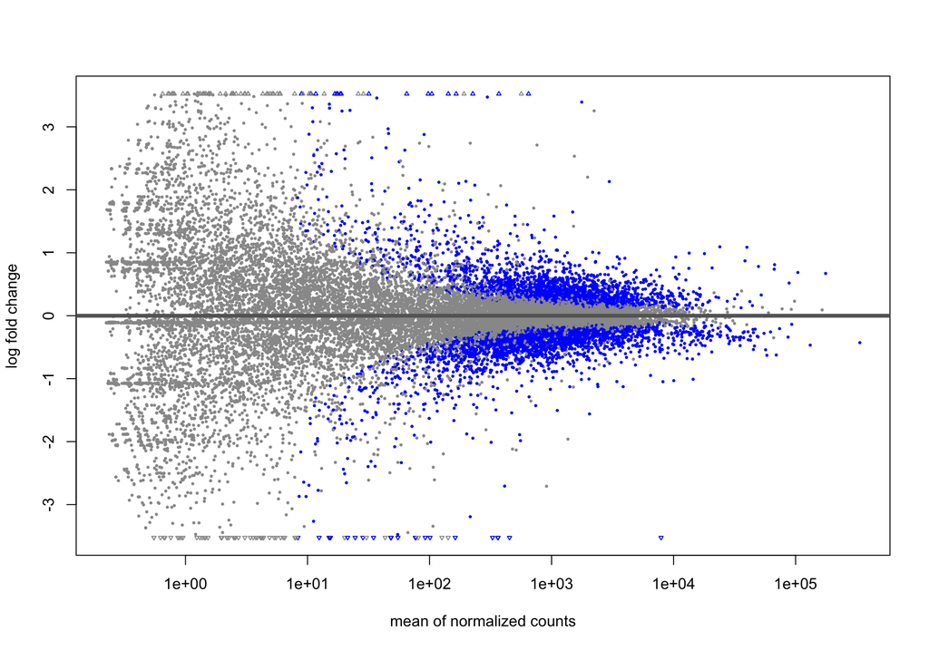

```r
##Corre la función plotMA sobre el objeto de los resultados
plotMA(res)
```

Nota: Existe una sobre-estimación del log2FoldChange para genes poco abundantes (media de cuentas normalizadas baja). Para corregir la sobre-estimación del log2FoldChange para dichos genes sin afectar los valores de aquellos con mayor abundancia usamos la función `lfcShrink()` de la librería `apeglm`

```r
res_shrink <- lfcShrink(dds = dds, res = res, coef = "Treatment_siRNA_NRF2_vs_siRNA_control"
, type = "apeglm")
```

```
## using 'apeglm' for LFC shrinkage. If used in published research, please cite:
##     Zhu, A., Ibrahim, J.G., Love, M.I. (2018) Heavy-tailed prior distributions for
##     sequence count data: removing the noise and preserving large differences.
##     Bioinformatics. https://doi.org/10.1093/bioinformatics/bty895
```

```r
summary(res_shrink)
```

```
##
## out of 21299 with nonzero total read count
## adjusted p-value < 0.1
## LFC > 0 (up)       : 2271, 11%
## LFC < 0 (down)     : 2660, 12%
## outliers [1]       : 26, 0.12%
## low counts [2]     : 5778, 27%
## (mean count < 8)
## [1] see 'cooksCutoff' argument of ?results
## [2] see 'independentFiltering' argument of ?results
```

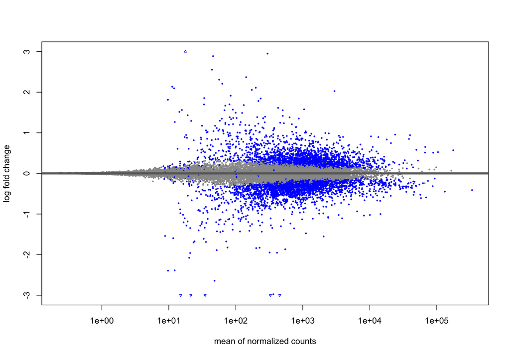

```r
plotMA(res_shrink,  ylim = c(-3, 3))
```

#### Volcano plot

De manera similar al MA-plot, el volcano plot muestra la distribución de los genes diferencialmente expresados graficando el -log10(padj) en el eje “Y” y el log2FoldChange en el eje “X.” Usa la función personalizada volcanoplotR del script de funciones:

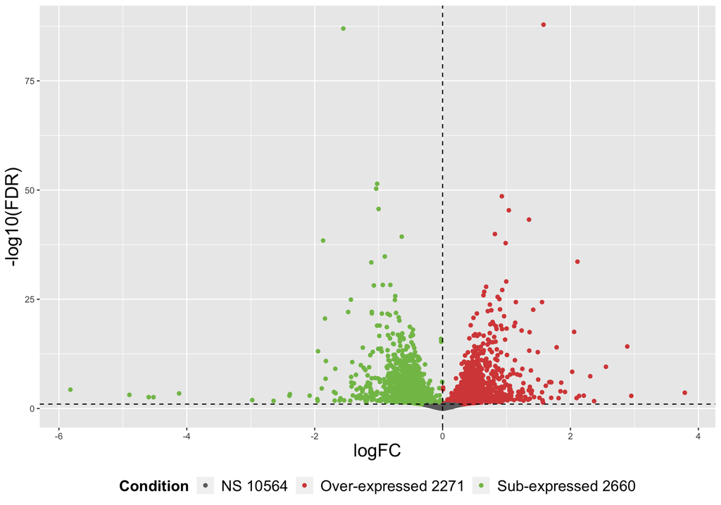

```r
##En los argumentos logfc y padj utiliza los mismos valores empleados en la función results
res_shrink <- as.data.frame(res_shrink)
volcanoplotR(res_shrink, logfc = 0, p.adj = 0.1)
```

Utiliza la función `glimmaVolcano()` para generar un volcano plot interactivo

#### Heatmap

El mapa de calor o *Heatmap* permite visualizar los genes diferencialmente expresados, a nivel de cuentas normalizadas, y el agrupamiento de las muestras con respecto a la expresión de dichos genes.

Para generar un Heatmap, sigue estos pasos:

1. Obten la matriz de cuentas normalizadas:

```r
norm_counts <- counts(dds, normalized = T)
```

2. Guarda un data.frame con los resultados de los genes mostrando expresión diferencial significativa:

```r
deg <- res_shrink %>% dplyr::filter(log2FoldChange > 0 & padj < 0.1 |
                                                     log2FoldChange < 0 & padj < 0.1)

head(deg)
```

```
##                  baseMean log2FoldChange      lfcSE       pvalue         padj
## ENSG00000000460  467.6023      0.4721205 0.11836789 9.277210e-06 0.0001217192
## ENSG00000001084 1889.3028     -0.2991140 0.09464064 4.368589e-04 0.0031869719
## ENSG00000001167 1068.3113      0.2413441 0.08978195 2.877301e-03 0.0149359373
## ENSG00000001461  564.0667     -0.2490246 0.08409560 1.186278e-03 0.0073086983
## ENSG00000001561  612.2146     -0.2536187 0.10372375 5.197697e-03 0.0240905329
## ENSG00000001617  996.1836      0.2917830 0.09054617 3.973259e-04 0.0029527889
```

3. Usando la librería de `pheatmap()` obten la gráfica

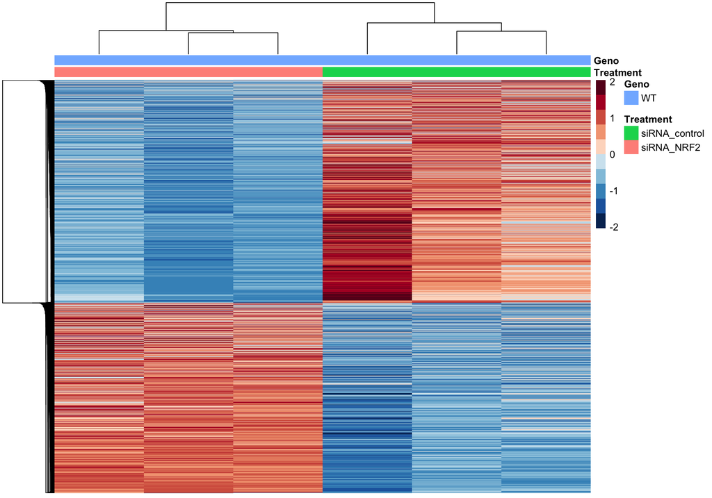

```r
##Genera una paleta de colores
RedBu <- brewer.pal(n = 10, name = "RdBu")
RedBu <- rev(RedBu)

pheatmap(norm_counts[rownames(deg), 1:6], ##Corta los genes con expresión diferencial de la matriz normalizada
         scale = "row", ##Calcula los valores z por fila (gen)
         color = RedBu, ##Nombre de la paleta de colores
         show_rownames = F, ##No mostrar el nombre de los genes en la gráfica
         show_colnames = F, ##No mostrar el nombre de las muestras en la gráfica
         clustering_distance_rows = "euclidean", ##Especifíca la medida de la distancia entre filas
         clustering_distance_cols = "euclidean", ##O columnas
         clustering_method = "single", ##Método de agrupamiento jerárquico
         border_color = NA,
         annotation_col = coldata[1:6, c(2, 6)]) ##Añadir información relacionada a las columnas)
```